# Crime Analytics: Visualization of Crime Incident Reports for Summar 2014 in San Francisco and Seattle

1. In this assignment, some *expoloratory analysis* is done on the **criminal incident data** from **Seattle** and **San Francisco** to visualize patterns and contrast and compare patterns across the two cities.
2. **Data** used: The real crime dataset from **Summer (June-Aug) 2014** for both of two US cities *Seattle* and *San Francisco* has been used for the analysis. These reduced datasets are available on the github repository: https://github.com/uwescience/datasci_course_materials/tree/master/assignment6.
3. Each figure (supporting the analysis) has one / few of the descriptions / takeaways / insights on top of it (as header), although the purpose of each analysis is self-explanatory.
4. Please Zoom (Ctrl+ in a browser) if required, to view the figures (e.g., read the axis labels) properly.
5. All of the analysis / visualization was done using R and with the library graphic grammar plot and should be easily reproducible.

### Crime of Category LARCENY/THEFT is most common in San Francisco, whereas CAR PROWL is most common crime in the University District of Seattle, during the Summer Months (as can be seen from the following figures).

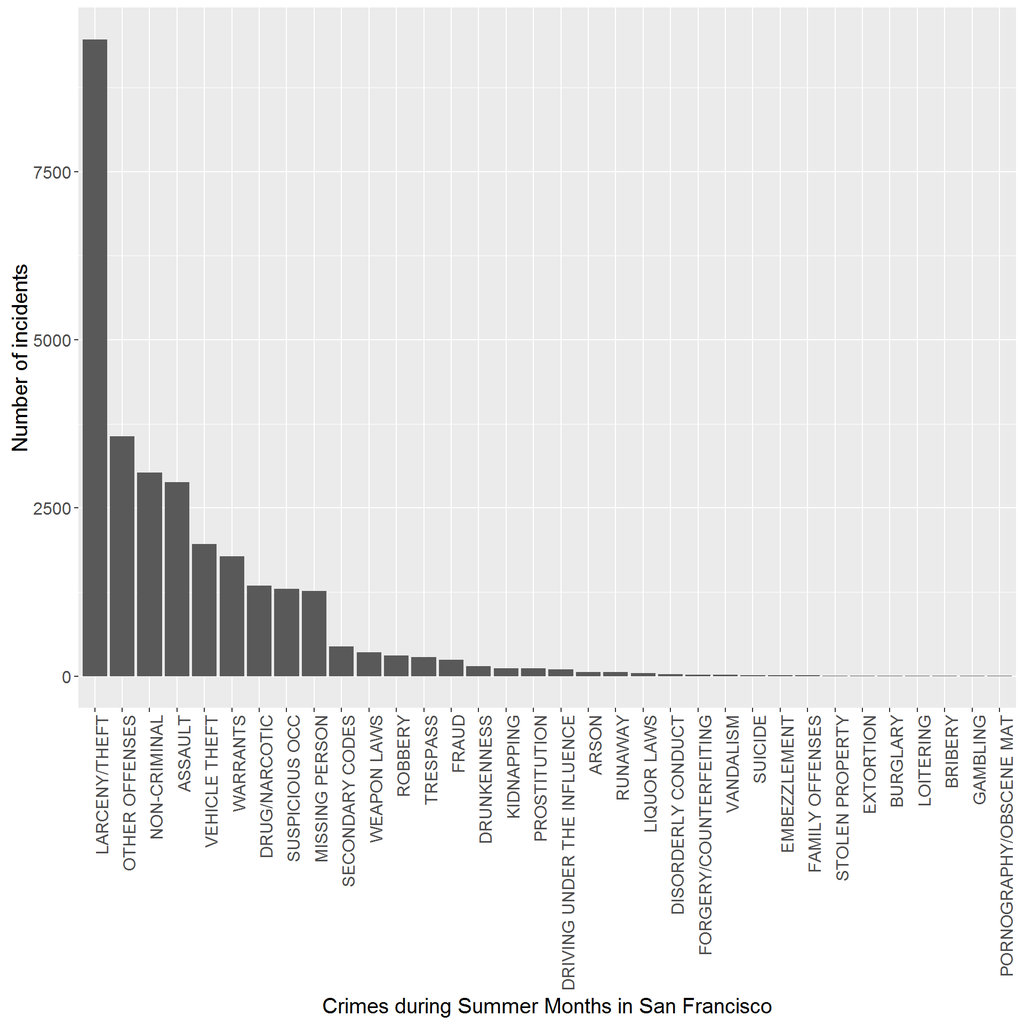

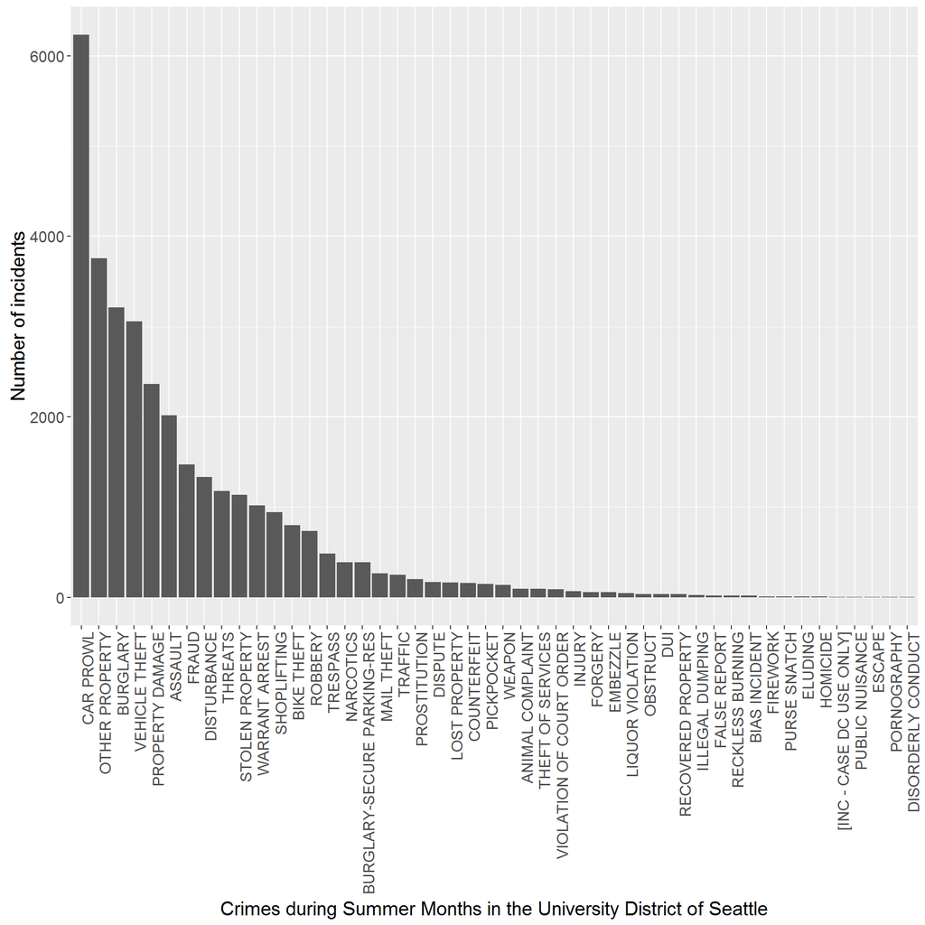

### Violent Crimes such as ROBBERY, WEAPON LAWS Increase at Night, whereas Crimes such as FRAUD, KIDNAPPING are quite common in the day time too, during Summer Months in San Francisco (as can be seen from the following figure).

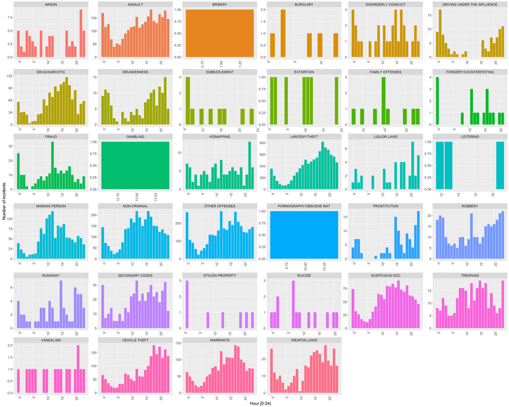

### Crimes such as CAR PROWL, BIKE THEFT Increase at Night, Crimes such as CAR PROWL, BIKE THEFT whereas Crimes such as FRAUD, SHOP LIFTING, STOLEN PROPERTY are quite common in the day time too, during Summer Months in the University District of Seattle (as can be seen from the following figure).

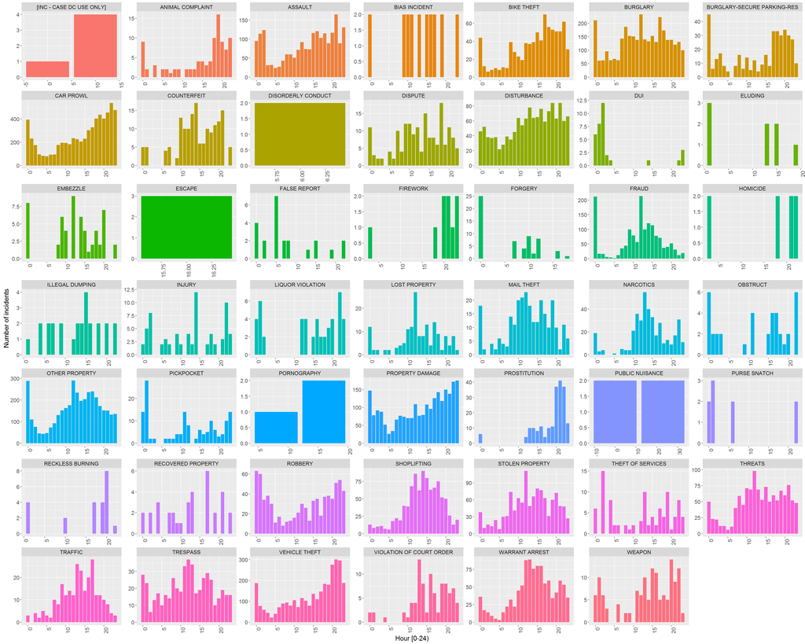

### The maximum number of crime incidents happened at 6 PM in the evening in San Francisco whereas the maximum number of crime incidents happened at 12 AM at night in the University District of Seattle, during the Summer Months (as can be seen from the following figures). (Here 12 AM denotes the time in between 12:00-12:59 AM inclusive, whereas 6PM indicates the time 6:00-6:59PM inclusive.)

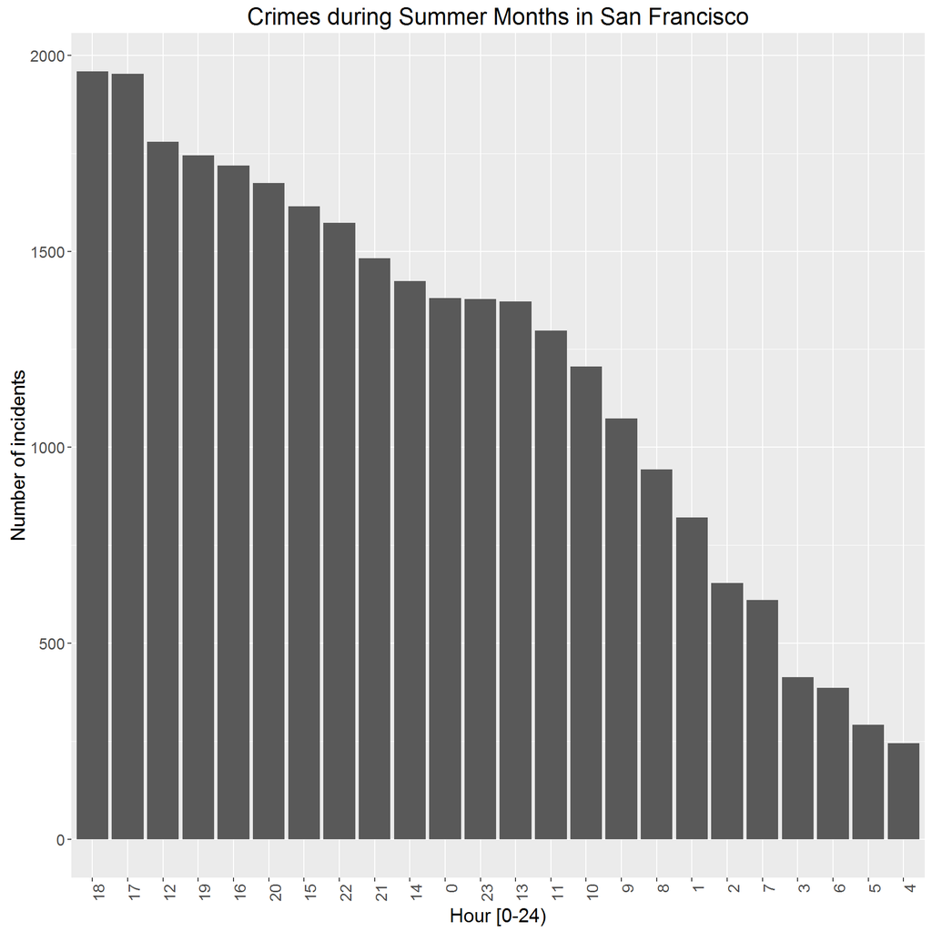

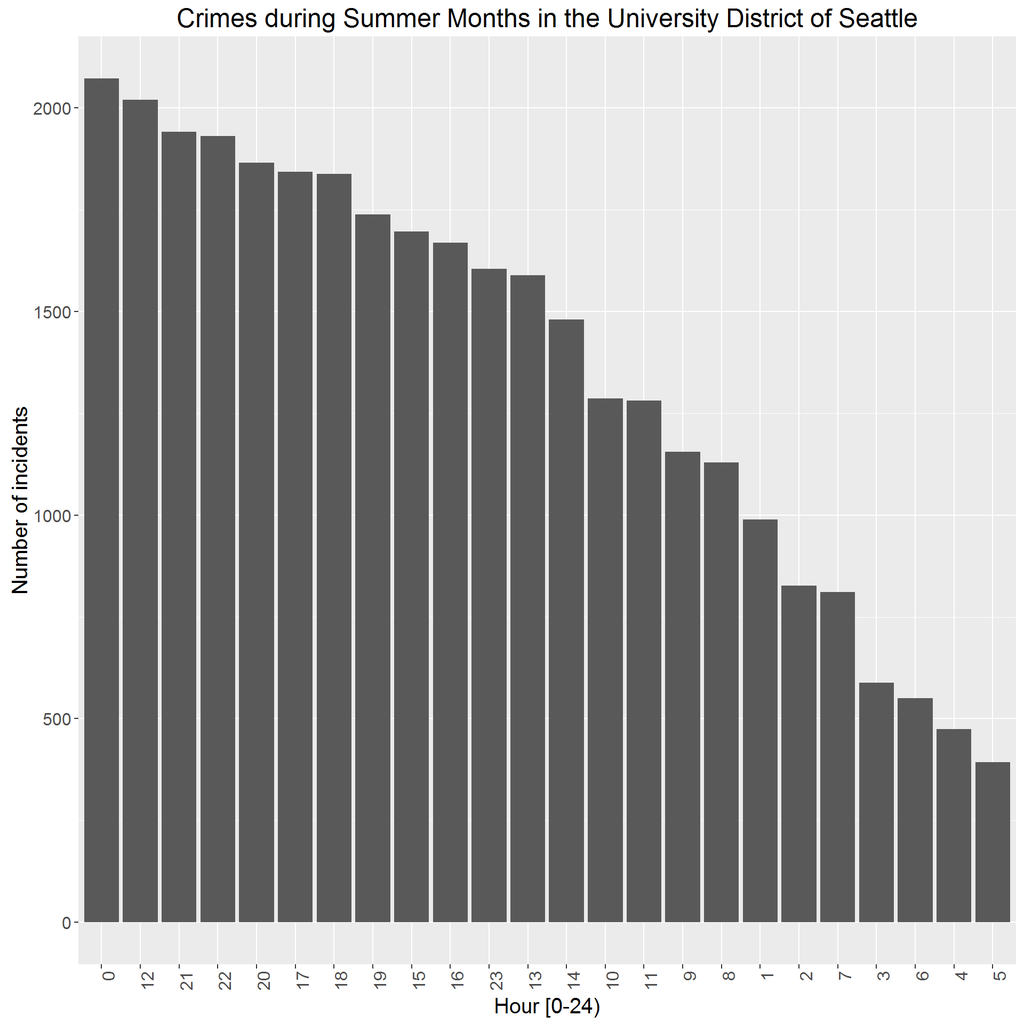

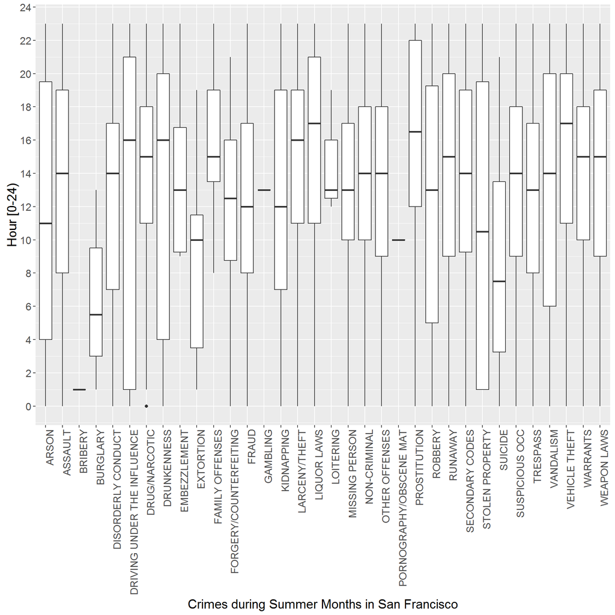

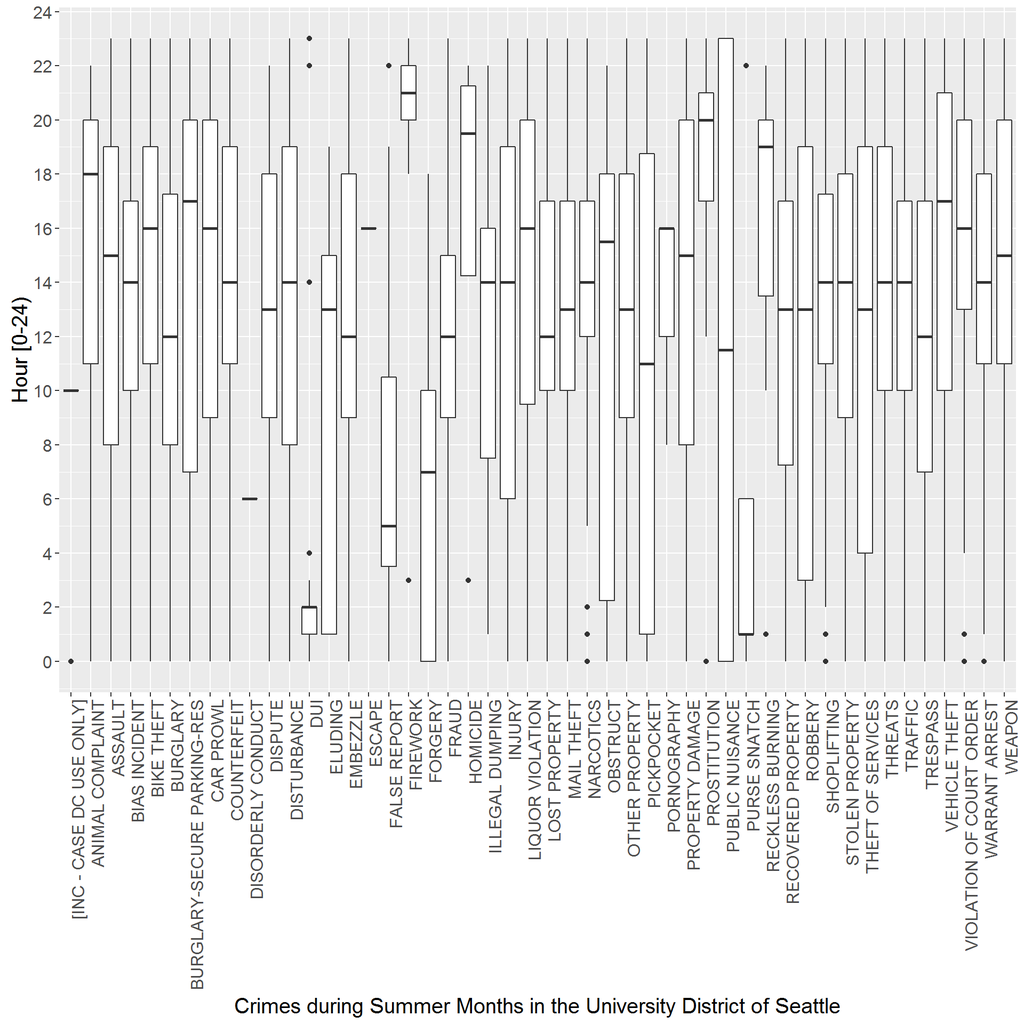

### The Crimes ROBBERY and KIDKNAPPING are most common in the INGLESIDE area, whereas the Crimes MISSING PERSON, SUICIDE, RUNAWAY, FRAUD are most common in MISSION area and the Crimes LARCENY/THEFT and LIQUOR LAWS are most common in the SOUTHERN area, during Summer Months in San Francisco (as can be seen from the following figure).

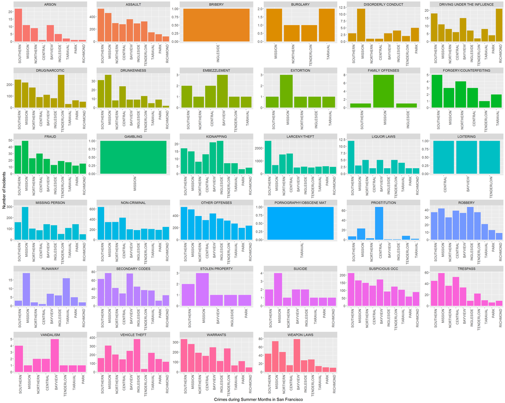

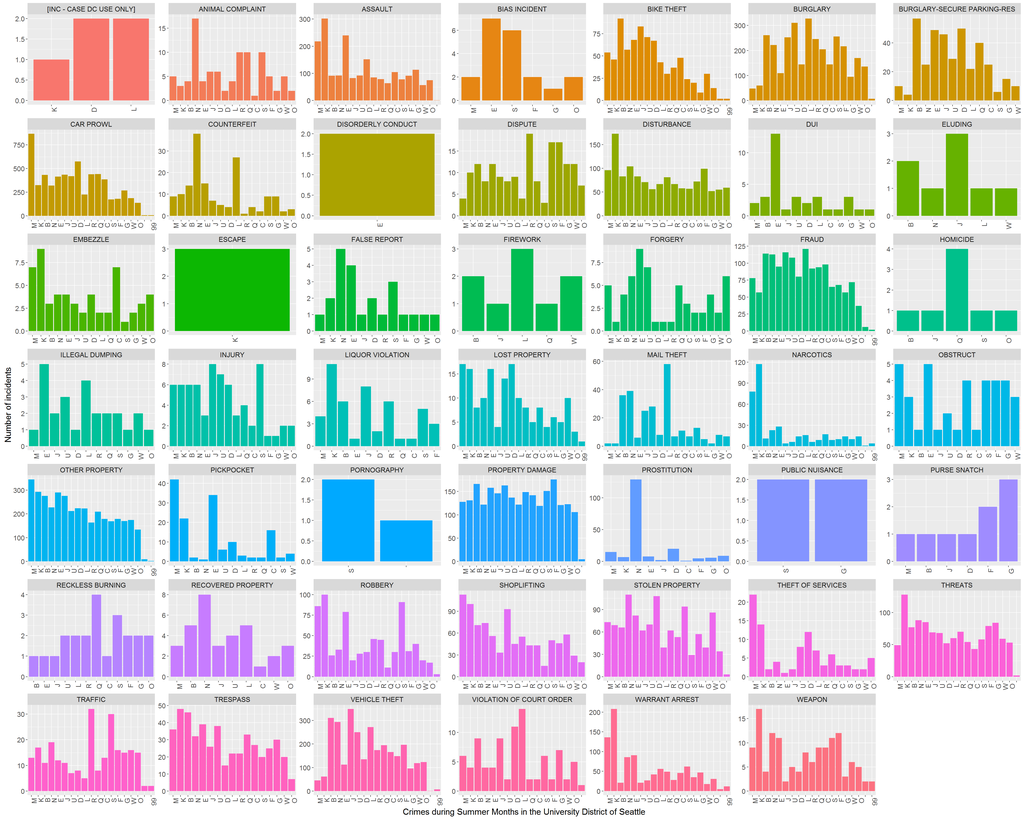

### The maximum number of crime incidents happened at SOUTHERN area in San Francisco whereas the maximum number of crime incidents happened at the M district sector in the University District of Seattle, during the Summer Months (as can be seen from the following figures).

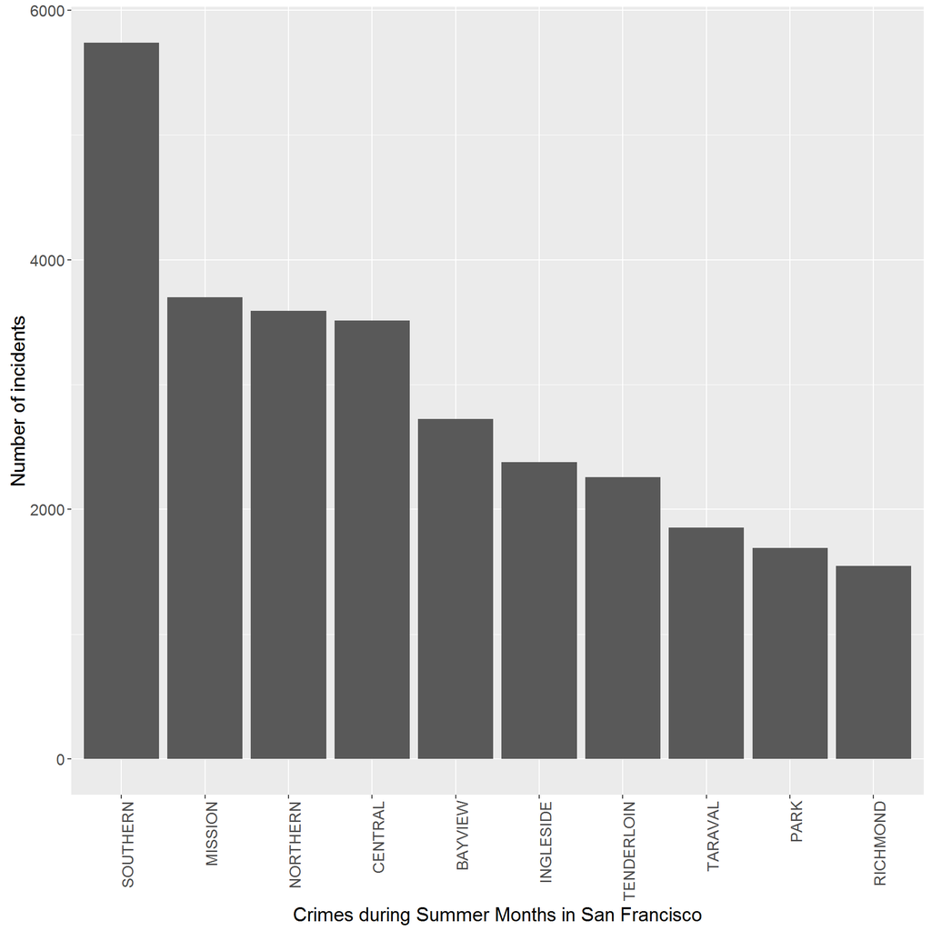

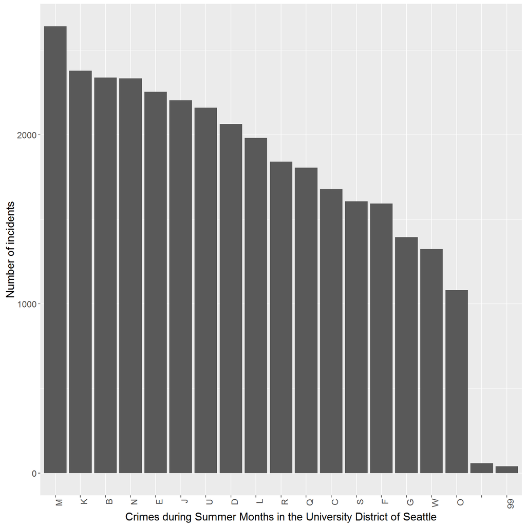

### The Crime LARCENY/THEFT is the most common in all the areas, VEHICLE THEFT is very common in the INGLESIDE area, whereas ASSAULT is common in BAYVIEW area, during Summer Months in San Francisco (as can be seen from the following figure).

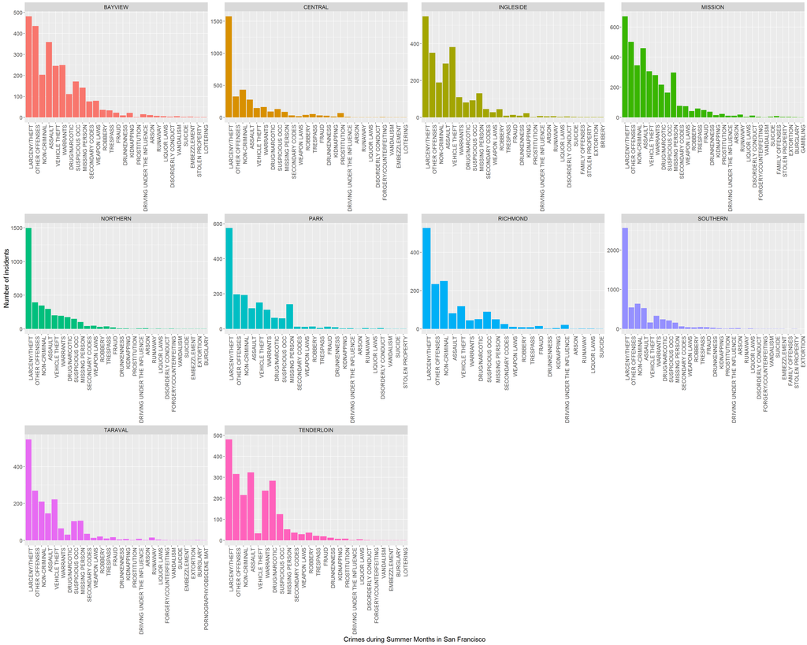

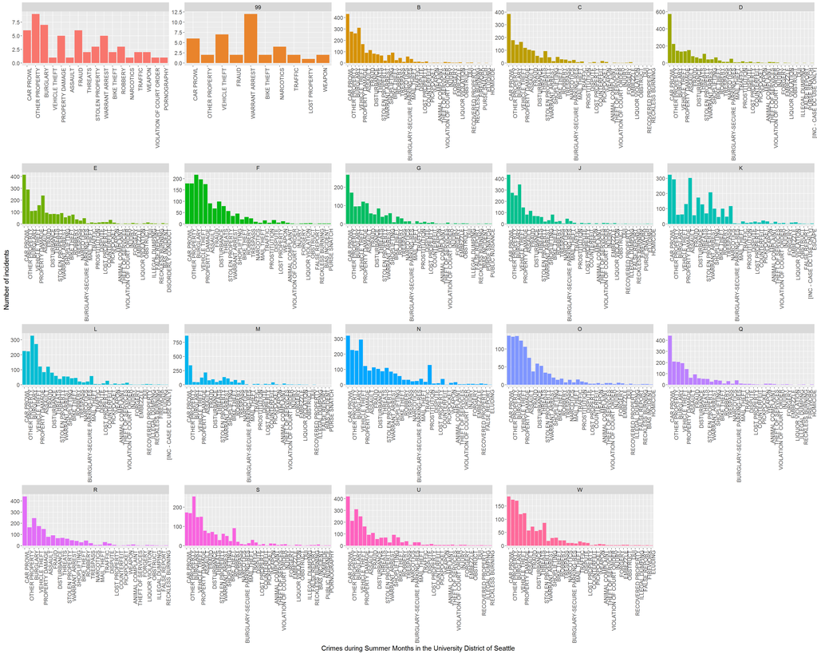

### Some Crimes (e.g., LIQUOR LAWS, PROSTITUTION) happened more on the Fridays, BRUGLARY happened mostly on Wednesday, during Summer Months in San Francisco (as can be seen from the following figure).

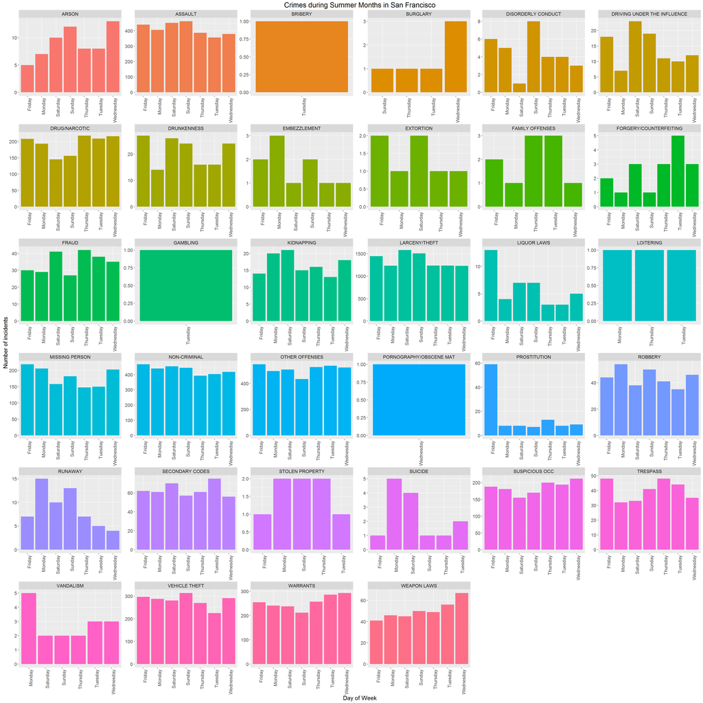

### Some Crimes (e.g., LOITERING, BRIBERY, BURGLARY) happened more on the beginning and the end of the months, whereas some of the crimes (ASSAULT, VEHICLE THEFT) are mostly uniform across all the days of a month, as found from the data during Summer Months in San Francisco (as can be seen from the following figure).

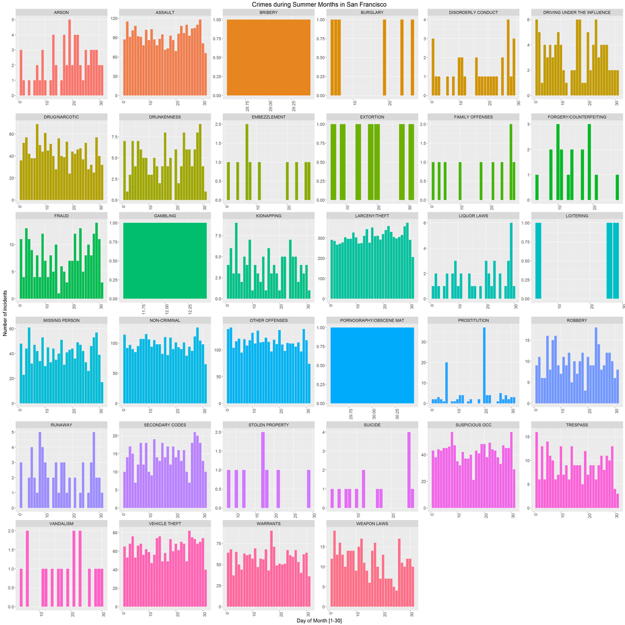

### Some Crimes (e.g., FIREWORK, HOMICIDE) happened more on the beginning and the end of the months, whereas some of the crimes (ASSAULT, BURGLARY, CAR PROWL) are mostly uniform across all the days of a month, as found from the data during Summer Months in the University District of Seattle (as can be seen from the following figure).

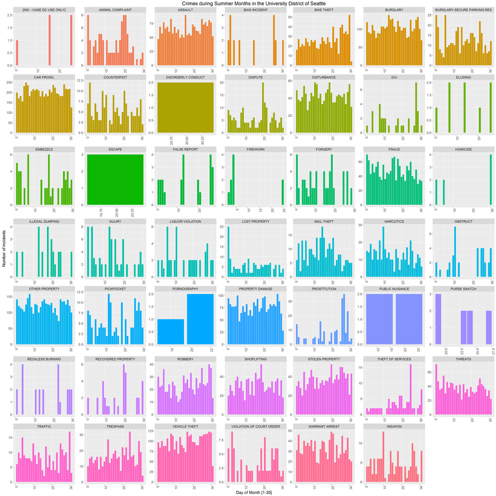

### The Crimes LARCENY/THEFT, FRAUD, SUICIDE, STOLEN PROPERTY, LIQUOR LAWS increase, whereas the crimes VEHICLE THEFT, MISSING PERSON decrease across all the three Summer Months (6:Jun, 7:July, 8:Aug) in San Francisco (as can be seen from the following figure).

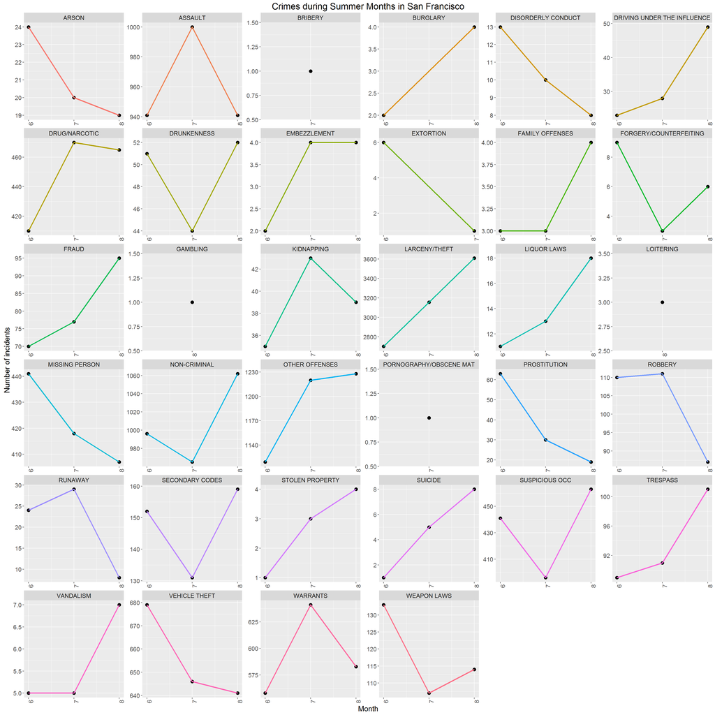

### The Crimes BIKE THEFT, THEFT OF SERVICES, INJURY increase, whereas the crimes VEHICLE THEFT, NARCOTICS decrease across all the three Summer Months (6:Jun, 7:July, 8:Aug) in the University District of Seattle.

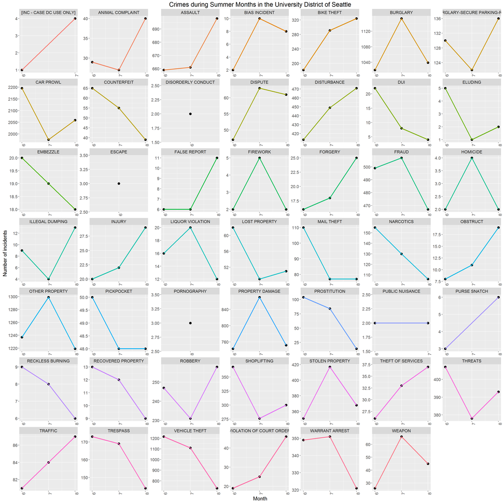

### The Crime LARCENY/THEFT is the most common in all the three Summer Months (6:Jun, 7:July, 8:Aug) in San Francisco. The Crime CAR PROWl is the most common during all the three Summer Months (6:Jun, 7:July, 8:Aug) in the University District of Seattle (as can be seen from the following figures).

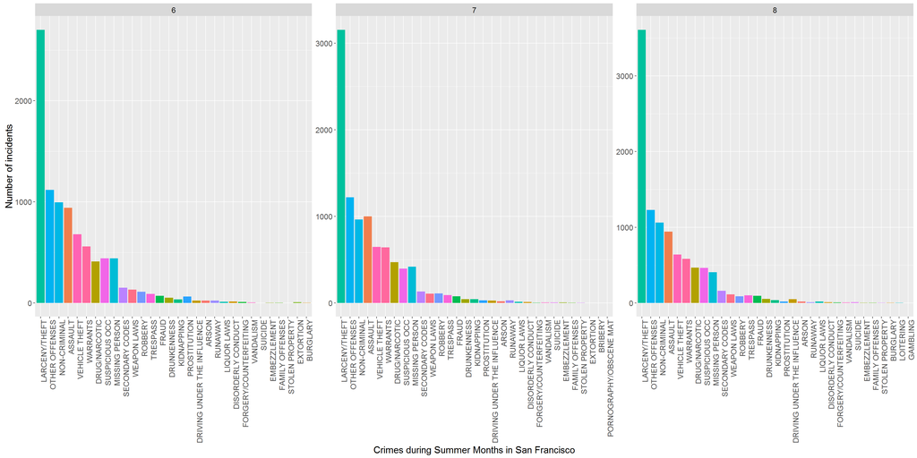

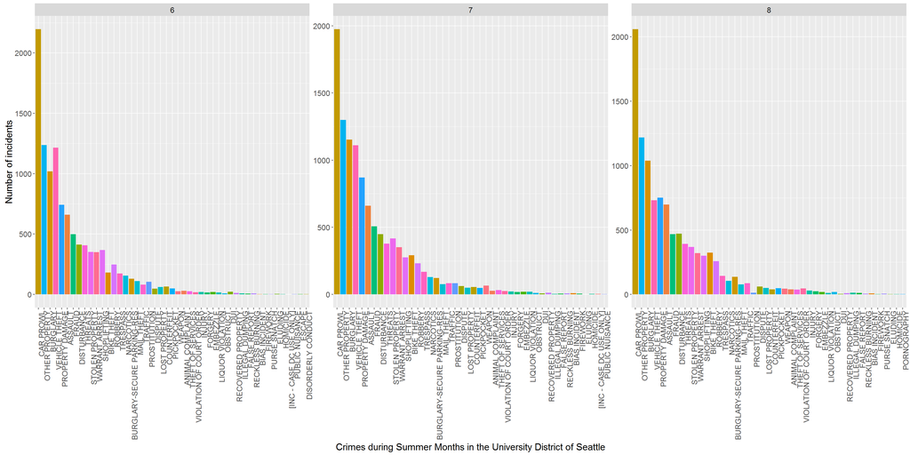

### The highest number of crime incidents happend in the month of August in San Francisco, whereas the highest number of crime incidents happend in the month of July in the University District of Seattle during the Summer Months 2014 (as can be seen from the following figures).

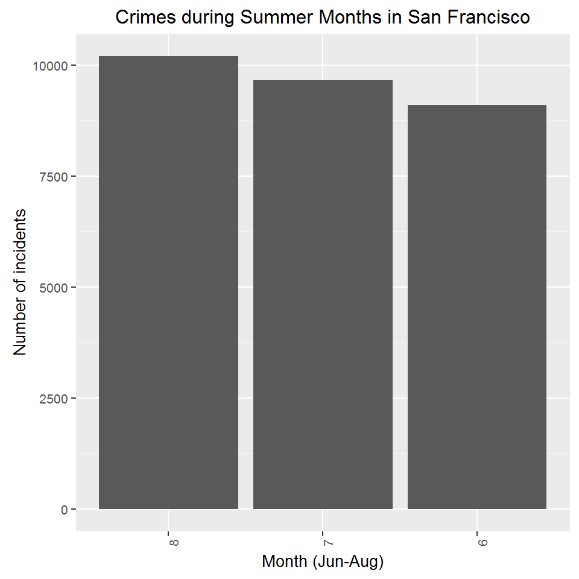

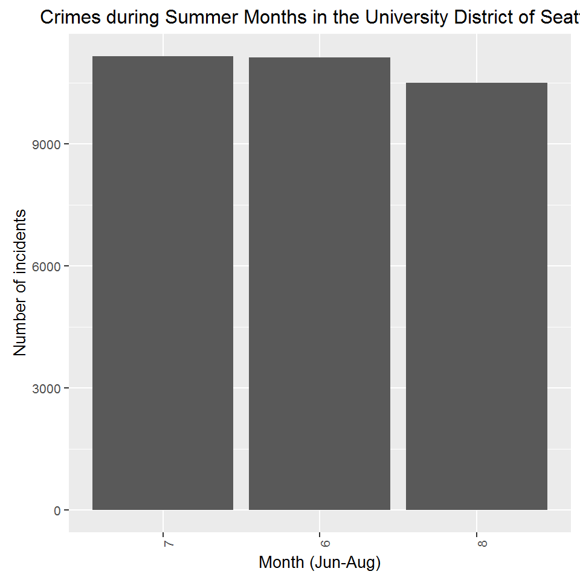

### The highest number of crime incidents happend on Friday in San Francisco, during the Summer Months (as can be seen from the following figure).

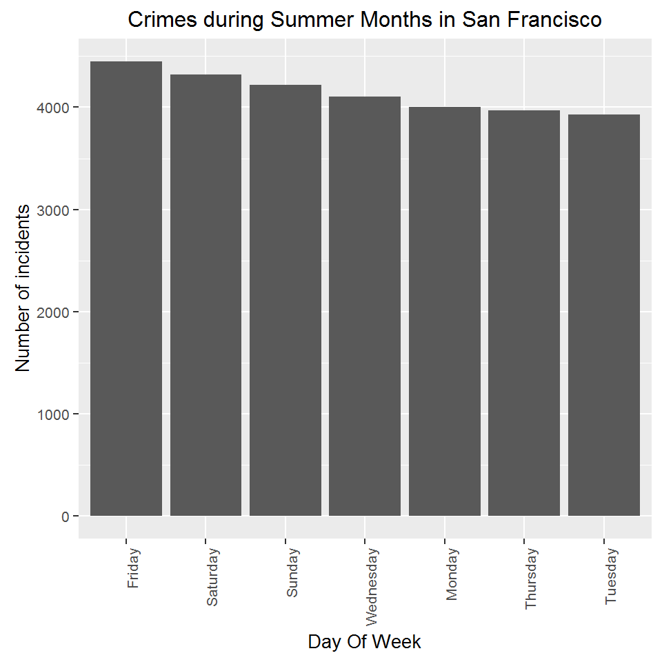

### The highest number of crime incidents happend on the 29th of a month in San Francisco, whereas the highest number of crime incidents happend on the 25th of a month in the University District of Seattle during the Summer Months (as can be seen from the following figures).

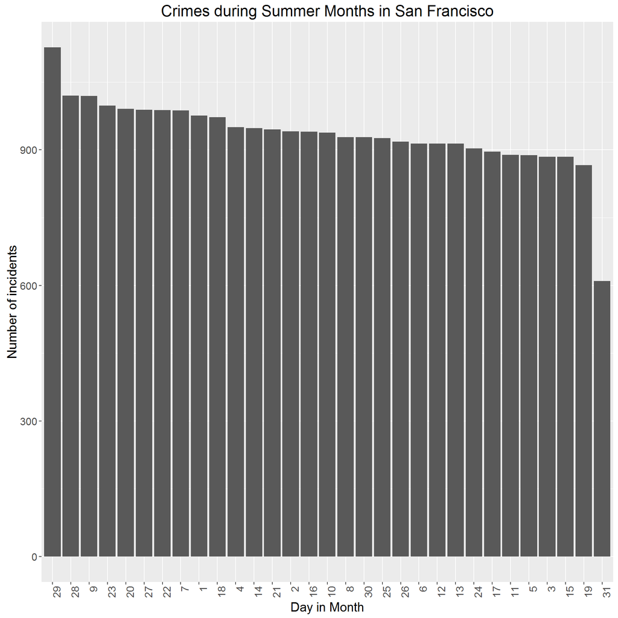

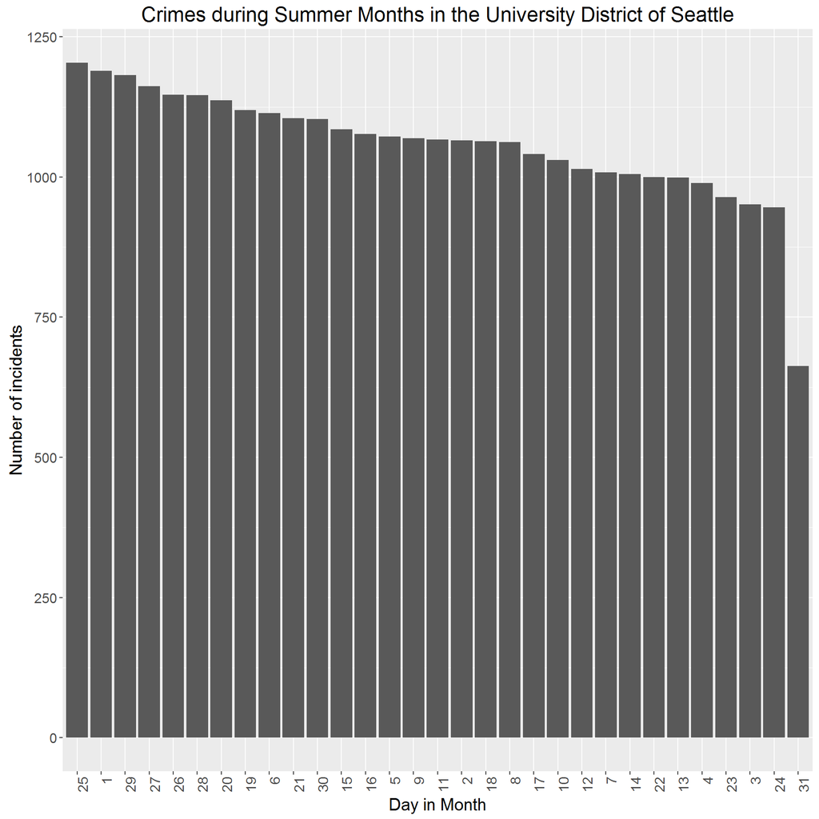

### The crime incident types MISSING PERSON and DRUNKENNESS tend to correlate with each other on a day-by-day basis (with a quite high correlation coefficient of 0.729) in San Francisco during the summer months. (The following figure also shows the day-to-day distribution of the number crime incidents as densities). **Please Zoom (Ctrl + in browser) to view the following correlation plot properly**.

[figure not shown]

### The crime incident type BIKE THEFT tends to correlate well with VEHICLE THEFT and TRAFFIC on a day-by-day basis (with a moderately high correlation coefficient of ~0.5) in the University District of Seattle during the summer months during the summer months. (The following figure also shows the day-to-day distribution of the number crime incidents as densities). **Please Zoom (Ctrl + in browser) to view the following correlation plot properly**.

[figure not shown]

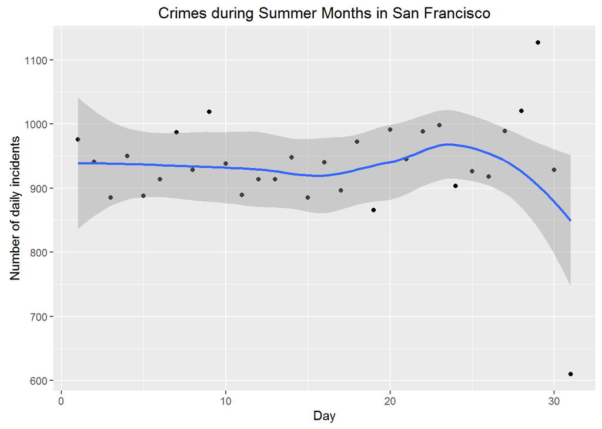

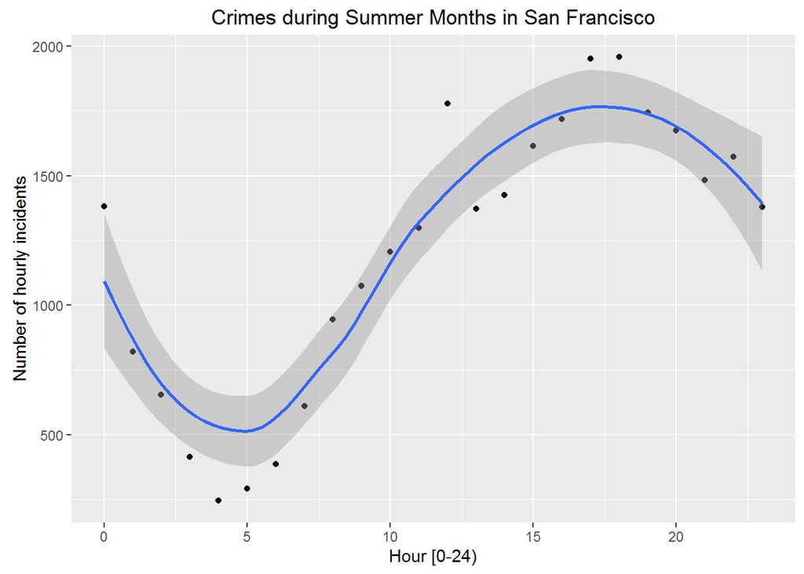

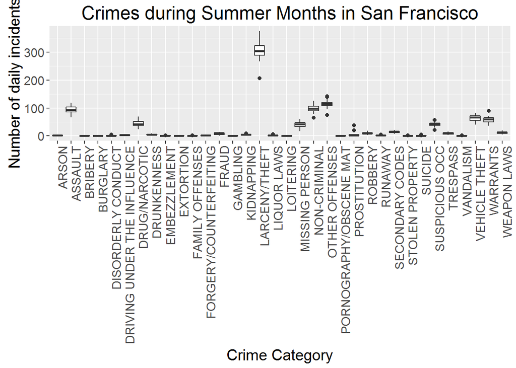

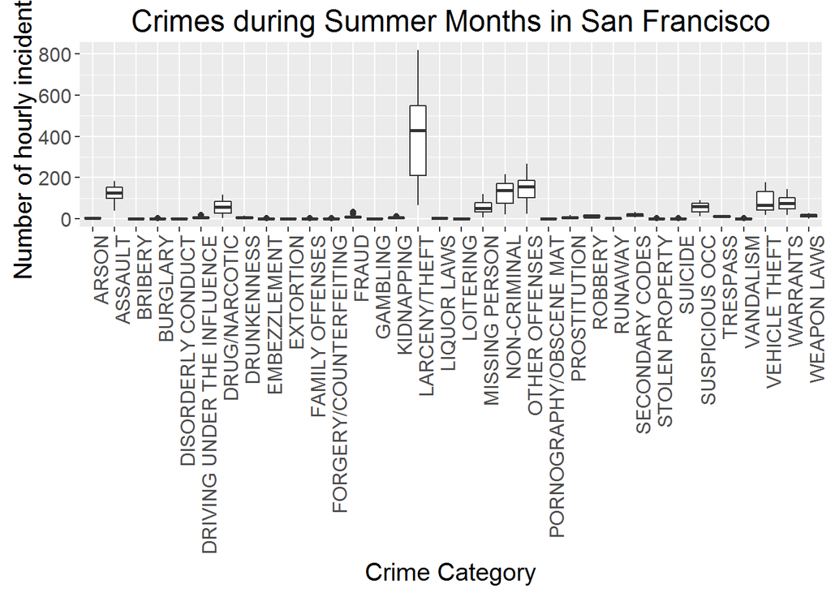